# 月報 2026/05, 2026/06

## Fri 01 May 2026

### 11:52:19

せっかく平日の木曜日と金曜日を有給休暇にして八連休を手作りしたのに雨続き. 昨日は外出できない程の雨ではなかったので出かけても良かったけど, 結果論だね. 大抵私がバイクでお出かけなんてすると雨が降るし, お出かけしなかったから雨が降らなかったわけだし.

あと Netflix を解約しそびれた. なんで？ 絶対気附いてたし解約したつもりだったのに. ただちょうど親が入院してて暇そうだったから, 親も見れるように設定してあげた.

GW は見れるものを全部見る.

- 地獄に堕ちるわよ (Netflix)
  - 大当たり
- 名探偵コナン ハイウェイの堕天使 (映画)
  - ハズレ
- 爆弾 (Netflix)
  - まあまあ当たり

あとは, もう何度も見た TRICK をまた見返してる.

## Sun 03 May 2026

### 16:08:34

昨日, 城ヶ島に行った. バイクに乗るのが目的なんでどこでも良かったんだけど, GW でもせめて空いてるところを, と思って選んだんだが全然混んでたね. 城ヶ島なんて江の島の下位互換なのは間違いないし, 前回行ったときは実際, 二つしか無い食堂はガラガラで簡単に入れたのに. 隠れた名所がついにバレてしまった. うーん, もう行かない.

今筋肉痛.

### 16:12:15 *gogyo キーボードレイアウト*

去年の12月から試してる試み. 完全に自分でキーボードレイアウトを考えてみようの続き. レイアウト自体は去年の12月からほとんどは変わってない.

キー配置は次の通り. ただしこれは日本語入力のときだけで, 英語入力はただの QWERTY 配列.

```
Ya Yi Yu Ye Yo G  Z  D  B  P
 A  I  U  E  O  K  S  T  N  H
   _  X  _  V  R  ん W
```

ここで `_` は使ってないの意味.

**特徴**

- 左手に母音を「あいうえお」で並べる
  - 「やゆよ」も母音だろの気持ち
- 右手に子音を「かさたなは」で並べる
  - 濁音「がぎぐげご」はすぐ上に置く
- 拗音は子音+「やゆよ」
  - `K Ya` で「きゃ」, `S Yu` で「しゅ」

前回からの変更点

- 名前を gogyo にした
  - GODAN キーボードを横に倒した形なので五段→五行
- ローマ字を一部破壊してる
  - `T N` を `M` の代用として使う
    - 例えば
      - `T N A` で「ま」
      - `T N Yu` で「みゅ」
    - 理由は `N` に近くしたいのと, 打ちやすさから
  - 「しょう」は `S Yo Yo` で打つ
    - 「しょう」って「しょ」+「う」ってよりは「しょ」+「お」じゃん
    - でも `Yo` から `O` は同じ指で縦動かすのが難しいから `Yo` 2回で「ょう」相当にした
  - 「しゅう」は `S Yu Yu` で打つ
    - 全く同様
  - 「しゃあ」は `S Ya Ya` で打つ
    - 全く同様
  - 「ふぁふぃふゅふぇふぉ」は `F Ya` ~ `F Yo` で打つ
  - 小文字は `X` の次に母音を打つ
    - 例えば
      - `X A` で「ぁ」
      - `X Ya` で「ゃ」

## Mon 04 May 2026

### 14:59:59

nvim 0.12.2 にした. こういうのめったにアップデートしないよね. GNU screen とかもそう. 使いたい learn.nvim が 0.12+ を要求したから. GW 残りは "ゼロから始める Lean 言語入門" をやる.

What's new in pip 26.1 - lockfiles and dependency cooldowns!  
pip 26.1 adds support for dependency cooldowns, experimental support for reading/installing from standard lockfiles (pylock.toml), fixes several long-standing limitations of the 2020 resolver, and drops support for Python 3.9.

ichard26.github.io/blog/2026/04/whats-new-in-pip-26.1/#fn:4

pip にクールダウン (min-release-age 的な) が追加されたらしい. 時代やね. それはいいんだが日数の与え方が `PnD` っていう形式で例えば 3 日間なら `P3D` と書く. なんだこれはと思ったんだが ISO 8601 でちゃんと定められてるの全く知らなかったね.

## Wed 13 May 2026

### 14:49:05 *賢いオウム*

- **1913年** : Andrey Markov がマルコフ連鎖のアイデアを発表
  - [Eugene Onegin というロシアの韻文小説に適用](https://alpha60.de/research/markov/DavidLink_AnExampleOfStatistical_MarkovTrans_2007.pdf) し, すでに n-gram モデルの原型を実装
- **1948年** : Claude Shannon が [A Mathematical Theory of Communication](https://web.archive.org/web/19980715013250/http://cm.bell-labs.com/cm/ms/what/shannonday/shannon1948.pdf) でいわゆる n-gram 言語モデルを紹介
- **1950年** : Alan Turing が [Computing Machinery and Intelligence](https://courses.cs.umbc.edu/471/papers/turing.pdf) でチューリングテストを提案
  - 人間と見分けがつかないほど自然に言語を操れることを人工知能の定義とする
- **1980年** : John Searle が [Minds, Brains, and Programs](https://home.csulb.edu/~cwallis/382/readings/482/searle.minds.brains.programs.bbs.1980.pdf) で Chinese Room という思考実験を発表
  - 言語を記号的に操作するだけのシステムは, 人間のように意味を理解しているとは言えないという批判
- **1990年** : Stevan Harnad が [記号接地問題](https://www.cs.ox.ac.uk/activities/ieg/e-library/sources/harnad90_sgproblem.pdf) を提起
  - 言語の意味は, それが指す実世界の対象や概念と結びついていなければならないという問題

### 15:37:01 *辣子鸡*

鶏の唐揚げの唐辛子和え, みたいな感じ. ちゃんとカリカリに仕上げるよ.

とりあえずコレ見て作ってみた.

[figure not shown]

1. 仕上げがベチャベチャ過ぎ
2. 鶏肉を食べるためのものなのでもっと量が欲しい
3. ネギは小ネギを

というわけで作り直した.

[figure not shown]

唐揚げをカリカリに揚げて最後までカリカリを保つのが大事

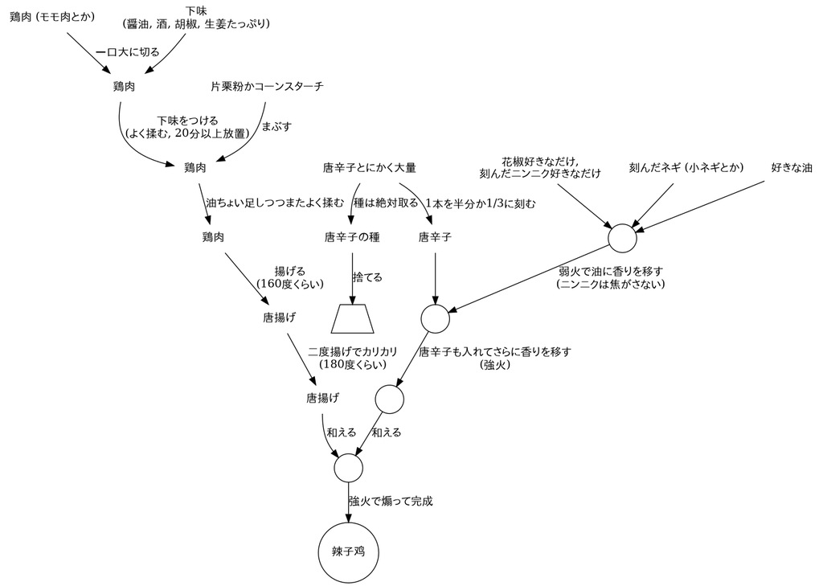

最後に砂糖小さじ加えてから追加で煽ったり（甘いは美味い）, 白ごま振り掛けたりとか何やっても美味しい. 唐揚げのカリカリが保たれてれば何でもいい. 唐辛子は避けながら食べること. 種を入れると避けれずに食べてしまうので出来るだけ先に取り除くこと.

## Fri 15 May 2026

### 18:52:26

```
  構成手順 (x を起点に7ステップ):
  s  = EML(x, 1)      # = exp(x)
  t  = EML(x, s)      # = exp(x) - log(exp(x)) = exp(x) - x > 0
  u  = EML(0, t)      # = 1 - log(t)            [t > 0 なので合法]
  v  = EML(u, 1)      # = exp(1 - log(t)) = e/t
  w  = EML(0, v)      # = 1 - log(e/t) = log(t) [v > 0 なので合法]
  ee = EML(s, 1)      # = exp(exp(x))
  -x = EML(w, ee)     # = exp(log(t)) - log(exp(exp(x))) = t - exp(x) = -x
```

### 18:55:52 *HSK5 21K5Q-test1*

```
- 听力: 16/45 => 35.55/100
- 阅读: 29/45 => 64.44/100
- 书写: 6/10 => 60.00/100
- 总分: 159.99/300 (NG)
```

## Mon 18 May 2026

### 14:50:20 *VRChat 写真のExif*

そういえば入ってても良いはずだと思って確かめたら案の定 Exif には以下の項目があった

```
   exiftool '/mnt/c/Users/cympf/OneDrive/画像/VRChat/2026-05/VRChat_2026-05-09_22-35-40.467_2560x1440.png'
ExifTool Version Number         : 12.76
File Name                       : VRChat_2026-05-09_22-35-40.467_2560x1440.png
Directory                       : /mnt/c/Users/cympf/OneDrive/画像/VRChat/2026-05
File Size                       : 3.7 MB
File Modification Date/Time     : 2026:05:09 22:35:40+09:00
File Access Date/Time           : 2026:05:18 12:17:44+09:00
File Inode Change Date/Time     : 2026:05:09 22:35:40+09:00
File Permissions                : -rwxrwxrwx
File Type                       : PNG
File Type Extension             : png
MIME Type                       : image/png
Image Width                     : 2560
Image Height                    : 1440
Bit Depth                       : 8
Color Type                      : RGB
Compression                     : Deflate/Inflate
Filter                          : Adaptive
Interlace                       : Noninterlaced
Creator Tool                    : VRChat
Author                          : （枚方）
Create Date                     : 2026:05:09 22:35:40.6609034+09:00
Modify Date                     : 2026:05:09 22:35:40.6609034+09:00
Date/Time Modified              : 2026:05:09 22:35:40.6609034+09:00
Title                           :
World ID                        : wrld_30716c54-3565-42f7-b7c5-d398ef4faac5
World Display Name              : ポピー横丁-Poppy Street-
Author ID                       : usr_498971ed-e232-4da0-bba5-04d895329b21
Image Size                      : 2560x1440
Megapixels                      : 3.7
```

自分の画像なんで撮った人が自分なのは別にいいとして, ワールド情報が入ってるのはいいね.

去年2025年の3月のアップデートからこれが入っていたらしい. 最近といえば最近か. 全く知らなかった.

なんでこれ思ったかというと写真の右下とかにこっそりワールド名を入れちゃいたいなと思ったから. 本当にやるかはともかくだけど.

つまりこういうことも出来る:

```
exiftool *.png | grep 'World Display' | sed 's/^.* : //' | sort | uniq -c | sort -nr
```

```
     72 ポピー横丁-Poppy Street-
     27 VUdon Vehicles - Desert （Open Alpha）
     20 枚方線
     15 陽だまりビーチ
      8 路地裏学園2
      8 ［ ツクヨミ - TSUKUYOMI - ］超かぐや姫ǃ -Cosmic Princess Kaguya-
      7 星島工業工場見学
      7 仮想空間温浴施設 電脳の湯
      6 雨見温泉 Rainy hot spring
      6 Daybreak ⁄ 黎明
      5 夜の公園 - The Park At Night
      5 仙台 アーケード商店街 フォトグラメトリ
      5 ZAPZAPBATH
      4 Japan Shrine［early summer］
      3 Object Escape
      3 Keys
      3 ［JP］Tutorial world
      3 Apocalypse
      2 収容施設レベルX
      2 Zinnia
      1 表六甲-OmoteRokko-
      1 第九十九黄昏導路 - Twilight Conduit XCIX
      1 Birthday Celebration
```

一部検閲済み

### 15:32:45

VRChat 過ぎる話題を

[figure not shown]

[枚方｜note](https://note.com/vympfh) に分離する. ここにも書くと思うけど, ここは誰かに見てもらうことを目的にしてないし, たぶん見てる人は限られてるから. やっぱり不特定多数に見てもらう場所は私だって欲しい.

この note は大昔に気まぐれで書いた記事が残ってた.

他にどういうのを書いてる記事が盛り上がってるんだろうって見てみ, やはりそうだな, 1000 のいいねを超える記事はみんな揃って誰かの悪口を書いてるだけだ. 何か学術的な調査の体裁で悪口を書いてる記事もあり, 近寄りたくない.

### 19:41:51 *HSK5 21K5Q-test2*

- 听力: 23/45 => 51.11/100
- 阅读: 28/45 => 62.22/100
- 书写: 3/10 => 30.00/100
- 总分: 143.33/300 (NG)

## Tue 19 May 2026

### 13:00:27

Google App for Desktop 導入した. 便利だと思う. ランチャー（インストール済みのアプリの起動）+ファイル検索+web検索+AI検索が統一されてる. Google 製であることを除けば文句なし.

Power Toys にもランチャーがあったけど, あれは酷かった. mspaint って打ってもペイントが出てこない.

## Mon 25 May 2026

### 11:35:20 *ムラ/ノラ/ハラ(/ヤマ)*

[大地への取り組み](http://web.kyoto-inet.or.jp/org/gakugei/judi/forum/forum7/fo7009.htm)

ノラは野良. 野良仕事や野良猫など.

## Tue 26 May 2026

### 19:01:59 *日本語にも声調はある*

中国語の勉強始めて意識したこと. 何人かの中国人たちに日本語に声調があるのかと聞かれて, もちろんそんなものは無いと答えてきたがあれは嘘だった.

声調というかピッチ（高低）イントネーションのことだけど. 例えば「カラス」は HLL （カ＼ラス）なのだが, LHH（カラス）と発音するとなぜだかガラスに聞こえる. イントネーションで音を聞いてるところはある.

学習者にとっての重要性だとか, 二の次具合はあるけど, 無いわけじゃ無いよというのは言うべきだと反省した.

## Thu 28 May 2026

### 13:45:42

Google App for Desktop いらん. 消した. こんなもののために Alt+Space 奪われてるの最悪. あといつも window 自体はあるから Alt+Tab したらこいつがいるのも邪魔.

Powertoys の Windows コマンドパレットで十分. でもこれ Win+Alt+Space で固定なんだよな. これを Alt+Space に変えたい.

## Wed 03 Jun 2026

### 11:51:17 *スライド形式は悪*

発表において, もはやスライド形式を選ぶ必要はない. あれはただ OHP (プロジェクター) の時代の遺物に過ぎない. ちょうど現代のキーボードが, いまだタイプライターの呪縛から逃れらてないように.

スライドではページという制約があるが故, 情報を無理に削ったり, 強引に移動したりする必要がある. どうせ PC の画面共有してるだけでしょ. ただ縦に長い資料をスクロールしながら見せるだけでいい.

ところで最近は資料作りまで Claude Code に任せてる. 当初は Marp やらで Markdown を書かせてスライド形式にしてたが, 最近は敢えて「スライド形式で」とは指定せず自由に Markdown を書かせたり, 或いは **直接** HTML で書かせている. もはや今みんな HTML 書けるから. 勝手にイケてるライブラリ使ってインタラクティブなグラフや SVG も入れてくれるし.

## Thu 04 Jun 2026

### 13:06:58 *Vivaldi からの乗り換え先を探す*

しれっと Proton VPN を標準装備したあたりから Vivaldi の動向が怪しいので乗り換え先を探す. 本当は今でも（かつての）Firefox + Vimperator が最高だったのでどうせならその方向性で. Grok にオススメ聞いて

1. qutebrowser
2. LibreWolf
3. Zen Browser

一旦 qutebrowser を試してみる. ガチガチにシンプルかつキーボードだけで操作してたあの頃の Vimperator のユーザーか開発者が絶対開発してるだろと分かる（想像で言ってる）.

Zen Browser は全く方向が違ってモダンを追求してる感じ. 本当の普段遣いは絶対こっちがいいな. こっちも並行して試してみよう.

## Sat 06 Jun 2026

### 22:01:33

クレカのグローバルポイント使う為だけにグローバルウォレットなるアプリを入れさせられ, さらにそれ単体だと何も出来ないので Google wallet にラップしてクレカとして使う, というのを設定した. 便利は便利だ. スマホの「おサイフケータイ」機能を使うの本当に初めて. ちゃんとスマホ起動して画面解除した状態じゃないとダメだけど. 画面真っ暗の状態でやると指紋認証が求められたが, 認証だけしたらスムーズに決済できた. アプリをいちいち起動するものだと思ってたが全く不要.

いいじゃんと思って, もしかして PASMO とかいうのもスマホに取り込んだら便利なのかと思ってやってみた. PASMO はモバイル PASMO という個別のアプリにするパターンと Google wallet にするパターンがあるらしいが, 基本モバイル PASMO のが便利らしい. 特に EX-予約とかでPASMO カードの番号を登録するとその PASMO で新幹線に乗れるんだが, モバイル PASMO に対応とは書いてた. Google wallet (Google Pay) については書いてなくて怖かったので.

モバイル PASMO アプリに登録, その場でプラスチックカードの方の物理 PASMO は使えなくなったらしい. さらに翌日午前5時に何かしらバッチの処理が走って整合性が取れるらしく, それまでは物理 PASMO もモバイル PASMO も「使えない」という状態になってたらしい. 次の日の昼に起動して, 操作すると物理カードにチャージされてた残高がモバイル PASMO に移動してた. そんで案内では, プラスチックカードの方はバス停や駅で返却したらデポジット 500 円も返すよ, というので行ってみたんだが,

- 都営地下鉄一軒目: 「移行完了していない。ここでは分からないからサポートに問い合わせて。」
  - よく分かってないおじさんだった
- 都営地下鉄二軒目: 「デポジットの 500 円も含めて実はもうモバイル PASMO に移行されているから、物理のカードは自分で適当に破棄してくれ」
  - その時は信じたが全然大嘘だった
  - 残高の履歴は全部アプリで見れるのでそんなそんな嘘すぐバレるのに
- 東京メトロ: これ京王で発行したやつだからそっち行って
  - そうなのかも

今住んでるところから京王はめったに行かない, 新宿行けばいけるか, だけど. もう 500 円のためにここまで働きたくないんで, これは記念ということで大事に保管することにした.

### 22:11:40

最近ジョギングとランニングを数分おきに交互に繰り返すってやつやってる. スマホをどうしたらいいか分からない. 雑にポケットに入れようとして今日しっかり落とし, 画面が割れた. いうてガラスの保護フィルムなのでそれが割れただけだろうと, 歩きながら次は柔らかいタイプのフィルムをポチった. 帰ってからフィルムだけ剥がしておくかと思って剥がしたら, 画面も割れてた.

- 秋葉にある修理: 画面交換 3 万円
  - うーん高い
- AliExpress にある交換キット: 1.5 万円
  - 交換の動画見てみて難易度は易しいと思った
  - うーんでも何かの間違いで壊したらもっと高くつく
- 買い替える
  - Google Pixel 9a -> Pixel 10a: 8万円
  - 日本限定色の Isai Blue とかいうのにしたら 8.7 万円でしかも届くの 6/30

結局買い替えることにした. 決め手は 10a がちょうど先月発売されたばっかだという事実. ちょうどいいタイミングだったと自分に言い聞かせる.

全然 9a 不満無く使えてたんだけどね. 最低 2 年は使うつもりだったけどね.

## Mon 08 Jun 2026

### 16:31:55

- う゜: う゜まれる (生まれる, mmareru)
- か゜: ごか゜く (語学, gogaku)

## Fri 12 Jun 2026

### 13:42:02

スマホ移行だるすぎて買い替えるたびに、もう二度と新しいスマホ買わないぞって決意してる

### 20:56:12

[一般ルービックキューブ NxNxN 解法 - aiura](https://cympfh.cc/aiura/cube-nxnxn)

cympfh.cc/aiura/cube-nxnxn

いつまで経っても完成版は出来ないので諦めてさっさと公開した. この svg 画像を出力させるのにツール作った.

GitHub - cympfh/isometric-cubeviz  
Contribute to cympfh/isometric-cubeviz development by creating an account on GitHub.

github.com/cympfh/isometric-cubeviz

## Mon 15 Jun 2026

### 16:18:56 *スマホを買い替えたが*

Google Pixel 9a の画面がしっかり割れ, 2-3万円出して修理に出すか悩んだ結果 10a を購入していた. まだ一週間も経ってないのにアスファルトの上に落とし, 画面側では無かったが縁が削れて背中の隅っこが凹んで見た目が悪くなった. というのが昨日の出来事で, それからずっと落ち込んでる.

## 2026-06-19 20:38:08 *夢日記*

Windowsのタスクバー、使う頻度に応じてサイズを大きくしたり小さくしたりするというアイデア

## Fri 26 Jun 2026

### 13:39:21

夢日記:でかいマンションに私は住んでて、エントランスから自分の部屋までの動線だけ勝手に掃除機で綺麗にした

### 16:35:03

[URL Expander](https://gegeek.com/urlxray.php)

gegeek.com/urlxray.php

短縮URLを展開してくれるサービス. 代わりにアクセスしてくれるので, discord のメール認証で使われる `click.discord.com` がどうしても私の手元からだとアクセスできないので使った.